# Covid-19 in Ireland

## Introduction

We perform simple mathematical modelling from government-published data, of recorded cases of Covid-19 in the Republic of Ireland.

For a refresher on exponential growth and epidemics, please see the 3Blue1Brown [video](https://www.youtube.com/watch?v=Kas0tIxDvrg).

## The Data

Data is published daily at an Irish Government [website](https://www.gov.ie/en/news/7e0924-latest-updates-on-covid-19-coronavirus/) and manually entered into a data-file. We use only the daily increases in cases and deaths.

```r
d <- read.csv(file="cases.csv", header=TRUE, sep=",")
d[is.na(d)] <- 0
d$date <- as.Date(d$date)
d$day <- as.integer(d$date - d$date[1])
d$total_cases <- cumsum(d$cases)
d$total_deaths <- cumsum(d$deaths)
ld <- tail(d, 1)
paste(ld$date, "total:", ld$total_cases, "cases,", ld$total_deaths, "deaths")
```

```
## [1] "2020-04-09 total: 6574 cases, 263 deaths"
```

## Exponential Phase

### Confirmed Cases

From the plot below, it is clear that growth up to mid-March, is in an exponential-growth phase. (The r-squared value indicates a good fit.)

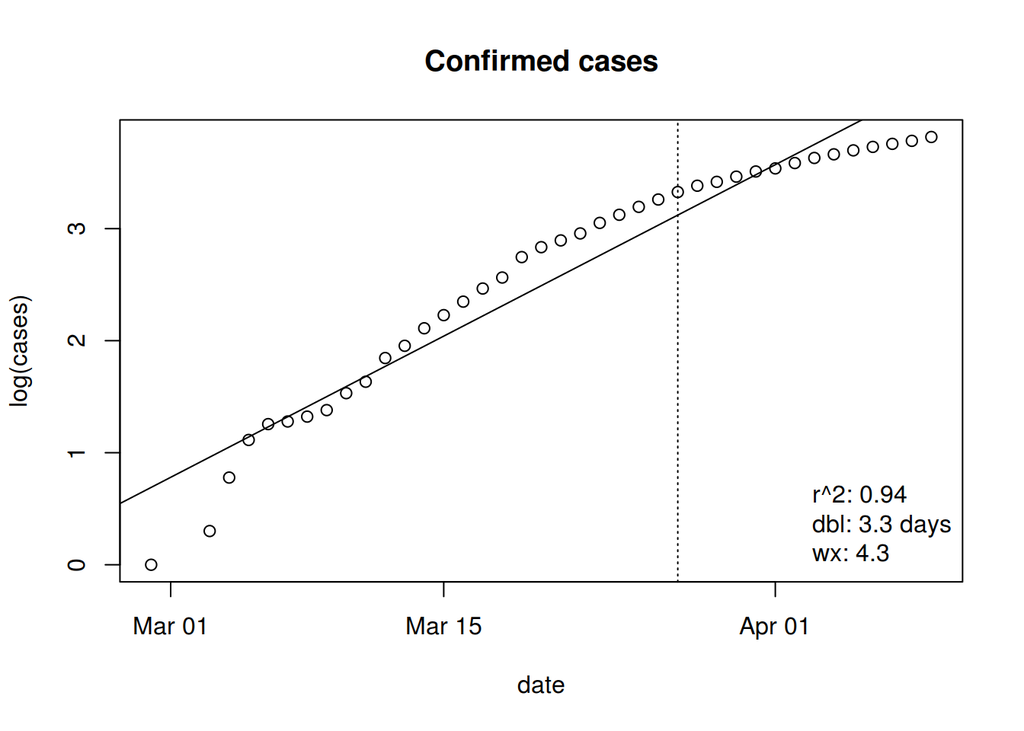

```r
fc <- log10(total_cases) ~ date
plot(fc, data=d, ylab="log(cases)", main="Confirmed cases")
m <- lm(fc, data=d)
abline(m)
r2 <- summary(m)$r.squared
dbl <- log10(2)/coef(m)[2]
wx <- 2**(7 / dbl)
legend("bottomright", bty="n", legend=c(paste("r^2:", format(r2, digits=2)), paste("dbl:", format(dbl, digits=2), "days"), paste("wx:", format(wx, digits=2))))
abline(v=as.Date("2020-03-27"), lty="dotted")
```

- the parameter $dbl$ in the plot is the doubling time in days, computed from the best-fit slope (cf. the [rule of 70](https://en.wikipedia.org/wiki/Rule_of_72))
- the parameter $wx$ is the weekly growth factor
- the vertical line is the day on which restrictions on movement were introduced

We can predict the number of cases after a week.

```r
pd <- Sys.Date() + 7
p <- 10**(predict(m, newdata=data.frame(date = pd)))
paste(pd, "predict", format(p, digits=2), "cases")
```

```
## [1] "2020-04-16 predict 83399 cases"
```

#### Notes on Testing

Becoming a statistic on this graph requires [time and effort](https://www2.hse.ie/conditions/coronavirus/coronavirus.html):

- call a GP
- convince them of symptoms
- be tested by appointment, either at home, or at a test centre
- wait for result

It is not clear what the average start-to-finish time is. However, the [PCR test](https://en.wikipedia.org/wiki/COVID-19_testing) can take up to 2 days; and on 22 March, the HSE [said](https://www.thejournal.ie/covid19-tests-ireland-5054061-Mar2020/) that the average waiting time to get a test was 4-5 days (and there was a backlog of 40000).

#### Prediction

Statistics on testing are only published weekly. However, we can get a rough estimate by combining the [latest figure](https://www.rte.ie/news/coronavirus/2020/0317/1123663-coronavirus-ireland/) with the latest number of cases:

```r
t <- read.csv(file="testing.csv", header=TRUE, sep=",")
t$date <- as.Date(t$date)
m <- merge(d, t, by="date")
lm <- tail(m, 1)
lt <- ld$total_cases * lm$tests / lm$total_cases
paste(ld$date, "positive rate:", format(lm$total_cases / lm$tests, digits=2), "tests:", format(lt, digits=2), "(estimated)")
```

```
## [1] "2020-04-09 positive rate: 0.13 tests: 48921 (estimated)"
```

(This assumes that the rate of positives remains constant over the interval since the test figures were published.)

From all this, it is possible that the testing system has been saturated and this is limiting the number of cases reported per day around this time. (This can be seen in a flattening of the graph above.)

In addition, the cases actually confirmed on a given day could be up to a week old.

### Deaths

While the extent of testing certainly influences the number of reported cases, a more reliable proxy for the spread of the disease should be the number of deaths.

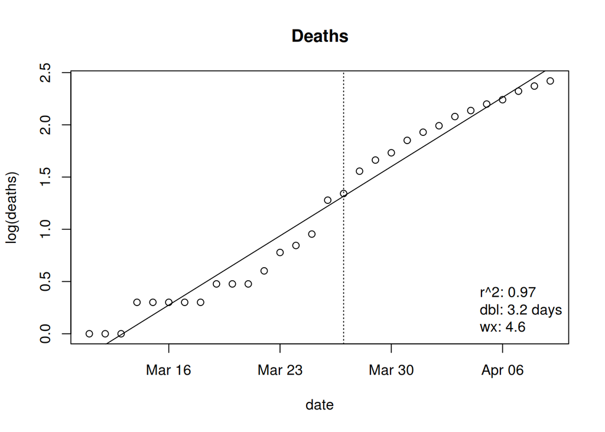

```r
fd <- log10(total_deaths) ~ date
dd <- d[which(d$total_deaths > 0),]
plot(fd, data=dd, ylab="log(deaths)", main="Deaths")
dm <- lm(fd, data=dd)
abline(dm)
r2 <- summary(dm)$r.squared
dbl <- log10(2)/coef(dm)[2]
wx <- 2**(7 / dbl)
legend("bottomright", bty="n", legend=c(paste("r^2:", format(r2, digits=2)), paste("dbl:", format(dbl, digits=2), "days"), paste("wx:", format(wx, digits=2))))
abline(v=as.Date("2020-03-27"), lty="dotted")
```

#### Notes on Deaths

A death due to the disease may be reported late, or not at all:

- Although deaths are reported every 24 hours it does not follow that all of the reported deaths occurred during that time
- If an untested patient dies are they tested post mortem?

#### Prediction

Predicting the number of deaths after a week:

```r
pd <- Sys.Date() + 7
p <- 10**(predict(dm, newdata=data.frame(date = pd)))
paste(pd, "predict", format(p, digits=2), "deaths")
```

```
## [1] "2020-04-16 predict 1622 deaths"
```

## Logistic Phase

In the real world, exponentials don’t continue indefinitely; after some time, they flatten into a [logistic](https://en.wikipedia.org/wiki/Logistic_function) (sigmoid) [curve](http://www.sci.wsu.edu/math/faculty/hudelson/logisticlesson.html).

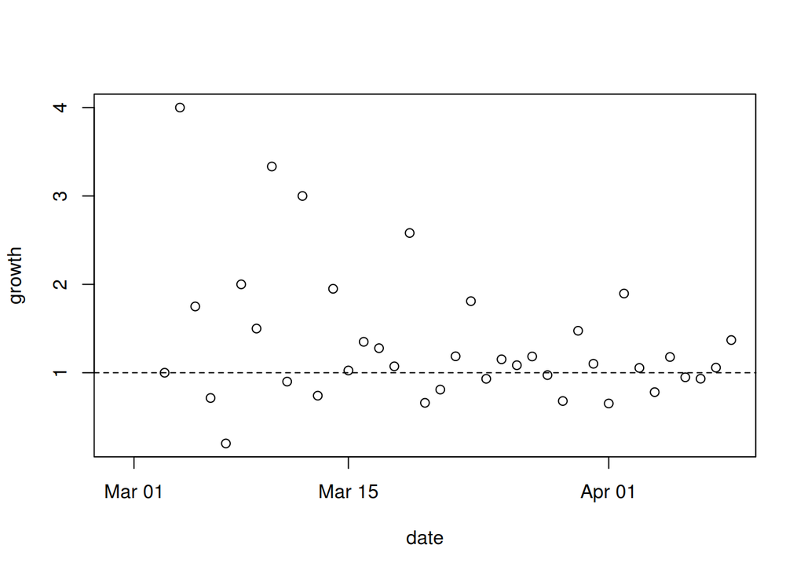

```r
d$lag.cases = c(NA,head(d$cases, -1))
d$growth = d$cases / d$lag.cases
plot(growth ~ date, data=d)
abline(h=1, lty="dashed")
```

The exponential phase ends when the growth rate slows to 1. (However this is not currently the case: the data is too noisy.)